# Restricted Cubic Spline

# Cubic Spline Function

Suppose a continuous variable x is divided into three intervals at cutpoints a and b, a model can be built between y and x by assuming piecewise linear in which there is a linear relationship for each of three intervals but with different slope.

A cubic spline curve is a piecewise cubic curve with continuous second derivative. Instead of a linear line, a cubic polynomial has a good ability to model a non-linear relationship by fitting a curve. Meanwhile, a piecewise cubic spline is smooth on the joint points (cutpoints) by forcing the first and second derivatives to be same on the joint points.

A piecewise cubic spline with two cutpoints a and b on the x variable has 5 regression coefficients in the model related to the variable x.

$$Y = \beta_0 + \beta_1X_1 + \beta_2X_2 + \beta_3X_3 + \beta_4X_4 + \beta_5X_5 + \cdots \beta_{\cdots}X_{\cdots}$$

- $X_1 = X$
- $X_2 = X^2$
- $X_3 = X^3$
- $X_4 = (X-a)^3_+$, any value of X less than a is set as zero.
- $X_5 = (X-b)^3_+$, any value of X less than b is set as zero.
- Notation
  - $U_+ = 0$, if $U <= 0$
  - $U_+ = U$, if $U > 0$

# Restricted Cubic Spline

The restricted cubic spline restrains the functions to be linear before the first knot and after the last knot. It has only $k - 1$ parameters must be estimated as opposed to $k + 3$ parameters with unrestricted cubic spline where $k$ is the number of knots.

$$f(X) = \beta_0 + \beta_1X_1 + \beta_2X_2 + ... + \beta_{[k-1]}X_{k-1}$$
where $X_1 = X$ and for $j = 1,...,k-2$,
$$X_{j+1} = (X-t_j)_+^3 - (X-t_{k-1})_+^3(t_k - t_j)/(t_k - t_{k-1}) + (X - t_k)_+^3(t_{k-1} - t_j)/(t_k - t_{k-1})$$

In case of four knots $t_1, t_2, t_3, t_4$ which means that there are four cutpoints with five intervals on a line, then $k = 4$, there should be $k - 1 = 3$ variables $X_1, X_2, X_3$ being generated and put into the model, and three corresponding parameters need to be estimated with the restricted cubic spline.

- $X_1 = X$
- For $j = 1,...,k-2$, when $k = 4$, $j$ has values of $1$ and $2$.
  - When $j = 1, k = 4$: $X_2 = (X - t_1)_+^3 - (X - t_3)_+^3(t_4 - t_1)/(t_4 - t_3) + (X - t_4)_+^3(t_3 - t_1)/(t_4 - t_3)$
  - When $j = 2, k = 4$: $X_3 = (X - t_2)_+^3 - (X - t_3)_+^3(t_4 - t_2)/(t_4 - t_3) + (X - t_4)_+^3(t_3 - t_2)/(t_4 - t_3)$
- Reference: [Frank Harrel, Hmisc Package, “rscpline.eval” Function](https://cran.r-project.org/web/packages/Hmisc/Hmisc.pdf)

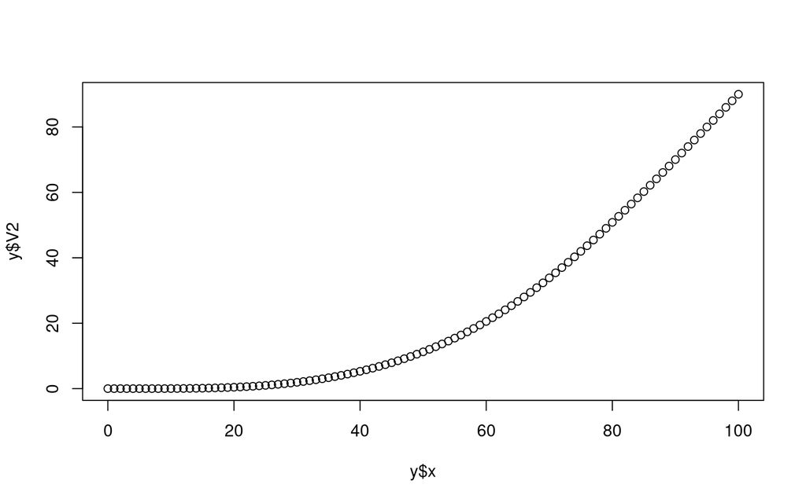

```r
library(Hmisc)
x <- seq(0,100,by=1)

knots <- quantile(x,c(0.05,0.35,0.65,0.95))
t <- quantile(x,c(0.05,0.35,0.65,0.95))

y <- rcspline.eval(x,nk=4,inclx = TRUE)
y <- as.data.frame(y)
## str(y)
## dim(y)

y$y2 <- (x >= t[1])*(x - t[1])^3 - (x >= t[3])*(x - t[3])^3*(t[4]-t[1])/(t[4]-t[3]) + (x >= t[4])*(x-t[4])^3*(t[3]-t[1])/(t[4]-t[3])
y$y3 <- (x >= t[2])*(x - t[2])^3 - (x >= t[3])*(x - t[3])^3*(t[4]-t[2])/(t[4]-t[3]) + (x >= t[4])*(x-t[4])^3*(t[3]-t[2])/(t[4]-t[3])


tau <- (t[4] - t[1])^2
y$V2b <- y$V2*tau
y$V3b <- y$V3*tau
# View(y)

## sum(y$V3b - y$y3)
## sum(y$V2b - y$y2)

plot(y$x, y$V2)
```

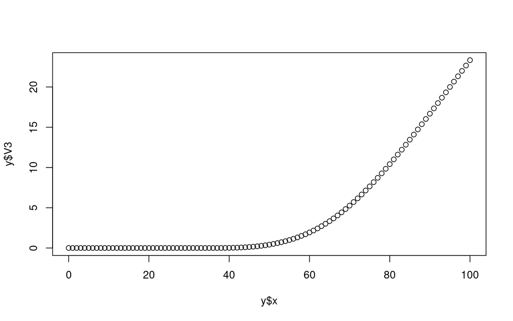

```r
plot(y$x, y$V3)
```